# compstatsR session 2: simulation workflows and distributed computing

18 October 2016

## Simulation workflows

## Simulations

- frequently part of Master's projects
- more accessible than analytical proofs
- often necessary for evaluating complex methods
- e.g. *power analyses* of complex experimental setups
- The [FiveThirtyEight election forecasts](http://fivethirtyeight.com/features/a-users-guide-to-fivethirtyeights-2016-general-election-forecast/) are simulation-based

## Simulations: input & output

- many inputs (e.g. varying parameters, problem dimensions, replicates)
- sometimes many outputs e.g. a variety of parameter estimates
- then condense parameter estimates to measures of accuracy and precision (mean squared error, bias, coverage, computation time …)

## Factorial experiments

- \(p\) parameters, \(\{n_1,n_2,\dots,n_p\}\) values for each parameter
- last dimension often = replications
- lots of `for` loops
- *checkpointing*: `save()` or `saveRDS()` frequently (enough) !

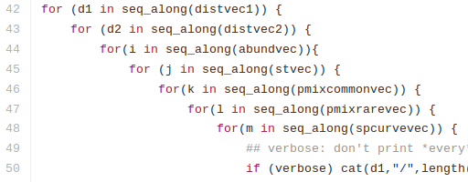

[source](https://github.com/bbolker/betararef/blob/master/inst/batchfiles/betasim_batch11.R%5D)

## Storing output

- don't grow structures
- fill with `NA` initially
- label everything
- `array()` with *named* `dimnames()`
- can summarize via `apply()` (and `sweep`)
- or converted to long format via `as.data.frame.table` or `reshape2::melt`
- summarize via split-apply-combine (e.g. `dplyr`, `group_by`+`summarise`)

## Storing output (example)

```r
v1_vals <- c(100,200,500)
v2_vals <- 1:10
v3_vals <- c("fast","slow")
res <- array(NA,
  dim=c(length(v1_vals),
        length(v2_vals),
        length(v3_vals)),
  dimnames=list(v1=v1_vals,
                v2=v2_vals,
                v3=v3_vals))
```

## Replication tricks

- for replication can use `replicate(n,<expression>)`
- … or `plyr::raply(n,<expression>,.progress="text")` (only one p!),
- **ALWAYS (ALWAYS) SET THE RANDOM NUMBER SEED** with `set.seed()`
- for easier diagnosis, set seed sequentially:  
  `for (i in 1:1000) { set.seed(1000+i); ... }`
- use `try()` to catch/skip bad values

```r
cur_result <- try(...)
if (is(cur_result,"try-error")) {
    ## maybe nothing
} else {
    ## store results
}
```

## alternatives to factorial designs

- fractional factorial experiments (Box, Hunter, and Hunter 1978)
- sensitivity analysis: pick typical values and vary *one parameter at a time* over sensible ranges
- Latin hypercube
- Sobol sequences

## Latin hypercube

- handy alternative to factorial design
- doesn't scale with problem dimension
- (use quantiles of marginal distribution)
- summarize output: marginal summaries, partial rank correlations

```r
dd <- data.frame(v1=1:100,v2=1:100)
dd[] <- lapply(dd,sample)
```

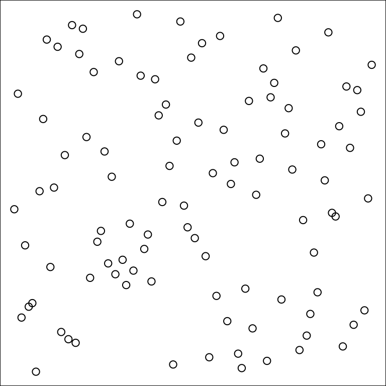

## Sobol sequences

- non-random, "low-discrepancy" sequences
- progressively fills space, evenly

```r
library(qrng)
m <- sobol(1000,2)
```

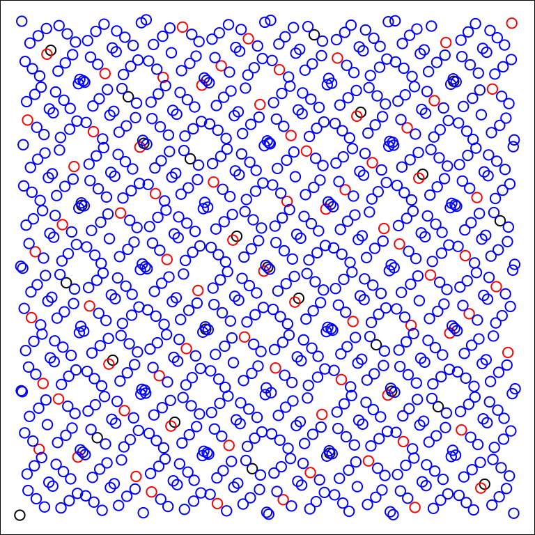

## Organization

- functions in a separate file
- you will always run many versions of your simulation
- `README` file

```
batch 1: ...
batch 2: as above, but with 6 different distances metrics ...
batch 3: as above, but split into 6 separate runs
batch 4: as above, but use new code with equal gamma diversity (= 10 species)
         in each case
```

## Distributed computing

## Distributed computing

- special case of *parallel* computing
- "trivially parallel"
- no communication needed between separate runs
- simplifies hardware, software architecture
- use multiple processors
  - single machine
  - cluster

## parallel package

- distribute computation in various ways - most easily across cores within a single machine, although also on multiple machines via SNOW ("Simple Network of Workstations")
- see `vignette("parallel")`

## parallel basics

- `detectCores()`
- `mclapply` (non-Windows only), `parLapply` (slightly more setup): 2 cores by default
- sometimes-tricky parts: dealing with random numbers (see `parallel` vignette) and (for complex problems) distributing necessary objects to all workers
- very simple for simple problems

```r
library(parallel)
mclapply(rep(4,5),rnorm)
```

## caveats

- added complexity
- need sensible decisions about chunking

```r
library(rbenchmark)
bcols <- c("test", "replications", "elapsed", "relative","user.self")
benchmark(mclapply(rep(4,1000),rnorm),
          mclapply(rep(1000,4),rnorm),
          lapply(4000,rnorm),
          columns=bcols)
```

```
##                            test replications elapsed relative user.self
## 3           lapply(4000, rnorm)          100   0.031    1.000     0.028
## 2 mclapply(rep(1000, 4), rnorm)          100   0.882   28.452     0.076
## 1 mclapply(rep(4, 1000), rnorm)          100   1.293   41.710     0.104
```

## foreach package

- similar to `parallel`
- fancier, larger range of back-ends
- `foreach()` and `%dopar%`
- `.combine`

```r
foreach(i=1:nrow(m), .combine=rbind) %dopar%
       (m[i,] / mean(m[i,]))
```

## distribution by hand

- no outside machinery
- chunk computations
- multiple `Rscript` or `R CMD BATCH` sessions
- assembly script

## chunking via shell scripts

- write a *shell script* (works on Unix, can be made to work on Windows …)
- see [example](https://github.com/bbolker/betararef/blob/master/inst/batchfiles/betasim_batch11gen)

  ```
  for ABUND in {1..41}; do
  sed -e "s/ABUND/$ABUND/g" batch_template.R > batch_$ABUND.R
  R CMD BATCH batch_$ABUND.R
  done
  ```

## chunking via command-line arguments

- `commandArgs` retrieves the arguments R was called with

```r
argvals <- commandArgs(trailingOnly=TRUE) ## chunk number: full run is (20)x50
## indexed from 0
batch_num <- as.numeric(argvals[1])
batch_size <- as.numeric(argvals[2])
cat(batch_num,batch_size,"\n")
```

```
for ABUND in {1..41}; do
     R CMD BATCH --vanilla "--args $ABUND" batchfile.R
done
```

- could also use R as your engine, e.g. `system()`

## assembly

- read in all files in directory (e.g. `list.files()`)
- `abind` or `do.call(rbind,...)` them together

## SHARCnet basics

- ask your advisor for access, register with Compute Canada
- logging in: `ssh`
- copying files: `scp`, `rsync`
- submitting jobs: `sqsub`
- checking jobs: `sqjobs`
- special stuff for R
  - install packages interactively, from head node
  - need to pick non-HTTPS mirror
  - need `module unload intel; module load r/3.2.3` in scripts

## References

Box, George E. P., William G. Hunter, and J. Stuart Hunter. 1978. *Statistics for Experimenters: An Introduction to Design, Data Analysis, and Model Building*. New York: John Wiley & Sons.